# PY0794: Lecture 10 - Worksheet

Dr. Thomas Pollet, Northumbria University, UK

2020-10-09

# Introduction.

This is a worksheet for use with [Lecture 10](https://tvpollet.github.io/PY_0794/Lecture_10/Lecture10-xaringan.html#1).

You have a [videos of me narrating these slides](https://www.youtube.com/playlist?list=PLeRo-gE9BBdx3zqeajoBGs6mM9SG0cNOM). Note that there are potentially minor discrepancies between the current set of slides and the one in the video. **The slide numbers refer to the current set.** I do not cover every single slide but you can code along!

If you answer correctly the colour of the box will change from red dashed to full blue! (Don’t worry about bonus questions, they are very much just that: a bonus!)

# Slides

## Simpson’s paradox / Ecological Fallacy (atomistic fallacy). (Slide 9)

Use your search skills in scholar google to find this information.

## Reasons to opt for multilevel models. (Slide 11)

Click the link with ‘country’ and have a look at the paper.

## Assumptions (Slide 13)

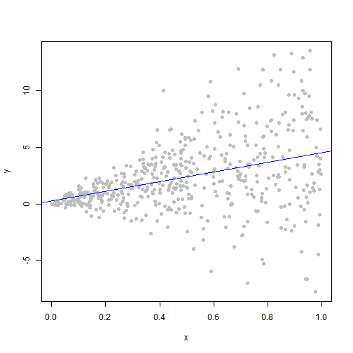

Go back over the slides for regression, week 4.

## nlme. (Slide 21)

True or False.

The fixed estimate of the intercept is the same to the 3rd decimal regardless of using ‘lme4’ or ‘nlme’.

## Model random intercept + fixed effect. (Slide 23)

Run the code on the slides.

What is the *t*-value for the fixed effect? (2 decimals)

## Model with random slope AND fixed effect. (Slide 34)

Run the code on the slides.

What it the *t* value for the fixed effect? (3 decimals)

## Model. (Slide 36)

Run the code on the slides.

What it the *p* value for the fixed effect of school average? (3 decimals)

## Try it yourself (Slide 37-38)

Use the previous slides, try and complete the questions. Speak to your group members if you run into issues

## Some diagnostic checks. (Slide 40)

True or False.

The residuals are normally distributed.

## Results. (Slide 48)

Run the code from the previous slides.

What is the bootstrapped standard deviation for ‘standLRT’? (3 decimals)

What is the bootstrapped mean for ‘schavg’? (3 decimals)

What is the bootstrapped maximum for ‘schavg’? (3 decimals)

## Exercise (Slide 52)

Complete the exercise and submit via Blackboard!

# Going further.

- Have a look at resources made by Alex and Sarah.
- Have a look at the resources listed at the end.

# Session Info.

Thanks to Lisa DeBruine for the [webex](https://cran.r-project.org/web/packages/webex/index.html) package. Please see [general disclaimer](https://tvpollet.github.io/disclaimer).

# The end…

[figure not shown]